# 和歌山県報告書

健康寿命

李鍾賛(jc lee, 滋賀大助教、数理統計学博士)

最終更新: 2021/02/26

# 1 データ情報：

- “DataFormat.csv” latest version 2021年2月10日

```r
# devtools::install_github(repo = "luka3117/JcPackage/OsakaUniv2020")

# 使用package
suppressMessages(library(readxl))
suppressMessages(library(dplyr))
suppressMessages(library(data.table))
suppressMessages(library(kableExtra))
suppressMessages(library(curl))
suppressMessages(library(tidyverse))
```

# 2 data import and pre-processing

- row data data 次元
- 94行と 168変数
- **168変数の中、一部の変数は男女の区別がないため、県単位のデータ(47行のデータ)として扱う**

```r
getwd()
```

```
## [1] "/Users/jlee/Dropbox/00000健康和歌山県/0 wakayamaPkg/working/slide"
```

```r
d<-read_csv("../..//data/DataFormat.csv", skip=1, locale = readr::locale(encoding = "CP932"))

d<-d[-95,]
d %>% dim()
```

```
## [1]  94 168
```

```r
d<-d %>% rename(key=X1)
d %>% DT::datatable()
```

|  | key | pref.id | sex | pref.E | pref.A | pref.J | 人口 | 受療率_入院_悪性新生物_2017 | 受療率_入院_心疾患_2017 | 受療率_入院_脳血管疾患_2017 | 受療率_外来_悪性新生物_2017 | 受療率_外来_心疾患_2017 | 受療率_外来_脳血管疾患_2017 | 病院数_2019 | 診療所数_2019 | がん治療認定医数_2020 | 循環器専門医数_2020 | 内視鏡専門医数_2020 | 75歳未満調整死亡率_悪性新生物_2018 | 書籍購入代金_2019 | 平均寿命_2015 | 健康寿命_2016 | 75歳未満調整死亡率_悪政新生物_2019 | 年齢調整死亡率_心疾患_2015 | 年齢調整死亡率_脳血管疾患_2015 | 60歳以上人口_2015 | 学習率_2016 | 読書率_2016 | 人口・世帯_年少人口割合2020 | … |
| --- | --- | --- | --- | --- | --- | --- | --- | --- | --- | --- | --- | --- | --- | --- | --- | --- | --- | --- | --- | --- | --- | --- | --- | --- | --- | --- | --- | --- | --- | --- |
| 1 | 1 | 1 | M | Hokkaido | Hkk | 北海道 | *** | 152 | 97 | 168 | 137 | 134 | 58 | 10.5 | 64.7 | 770 | 640 | 1370 | 99.8 | 39965 | 80.28 | 71.98 | 95.9 | 64.4 | 34.7 | 847206 | 30.3 | 33.1 | 10.9 | … |
| 2 | 2 | 2 | M | Aomori | Amr | 青森 | *** | 128 | 43 | 124 | 172 | 95 | 132 | 7.5 | 70.4 | 128 | 84 | 253 | 118.5 | 41814 | 78.67 | 71.64 | 112.6 | 76.8 | 52.8 | 208768 | 25 | 26.3 | 10.8 | … |
| 3 | 3 | 3 | M | Iwate | Iwt | 岩手 | *** | 100 | 49 | 132 | 183 | 105 | 153 | 7.4 | 71.6 | 168 | 117 | 247 | 96.5 | 42780 | 79.86 | 71.85 | 95.4 | 80.5 | 51.8 | 210555 | 27.7 | 29.2 | 11.3 | … |
| 4 | 4 | 4 | M | Miyagi | Myg | 宮城 | *** | 75 | 41 | 91 | 124 | 109 | 56 | 6 | 72.5 | 294 | 210 | 561 | 85.1 | 36956 | 80.99 | 72.39 | 84.6 | 65.1 | 43 | 337618 | 35.8 | 35.1 | 11.9 | … |
| 5 | 5 | 5 | M | Akita | Akt | 秋田 | *** | 136 | 49 | 119 | 175 | 145 | 96 | 7 | 83 | 129 | 94 | 224 | 102.2 | 41488 | 79.51 | 71.21 | 100.2 | 64.6 | 52.2 | 181995 | 26.6 | 28.8 | 10 | … |
| 6 | 6 | 6 | M | Yamagata | Ymgt | 山形 | *** | 112 | 51 | 108 | 190 | 135 | 92 | 6.3 | 85.3 | 138 | 107 | 241 | 87 | 38189 | 80.52 | 72.61 | 87.1 | 66.6 | 43.8 | 189952 | 30 | 27.4 | 11.6 | … |
| 7 | 7 | 7 | M | Fukushima | Fks | 福島 | *** | 105 | 53 | 100 | 170 | 175 | 124 | 6.8 | 72.9 | 172 | 160 | 382 | 93.3 | 45268 | 80.12 | 71.54 | 86.9 | 79.2 | 43.7 | 311787 | 28.9 | 30.1 | 11.6 | … |
| 8 | 8 | 8 | M | Ibaraki | Ibr | 茨城 | *** | 90 | 37 | 92 | 122 | 108 | 92 | 6 | 61.2 | 247 | 228 | 518 | 91.3 | 37708 | 80.28 | 72.5 | 89.7 | 66 | 46 | 454069 | 34.6 | 32 | 12.1 | … |
| 9 | 9 | 9 | M | Tochigi | Tch | 栃木 | *** | 102 | 44 | 105 | 146 | 79 | 87 | 5.5 | 75.5 | 234 | 193 | 547 | 88.6 | 37782 | 80.1 | 72.12 | 85.5 | 78 | 49.1 | 298944 | 32.1 | 30.5 | 12.3 | … |
| 10 | 10 | 10 | M | Gunma | Gnm | 群馬 | *** | 96 | 45 | 99 | 173 | 80 | 90 | 6.7 | 79.9 | 260 | 203 | 476 | 89.1 | 38384 | 80.61 | 72.07 | 80.5 | 71 | 39.5 | 307615 | 32.7 | 30.4 | 12.1 | … |

[output cut: 84 more lines]

## 2.1 変数名を英語に変換 :data名`d`

```r
var<-read.csv("../..//var_name_Eng.csv")
colnames(d)<-var$var_name_Eng
# d %>% DT::datatable()
```

### 2.1.1 変数名：和英対応表

```r
read.csv("../../JpnEng.csv") %>% DT::datatable()
```

|  | id | var_name_Jpn | var_name_Eng |
| --- | --- | --- | --- |
| 1 | 1 | key | key |
| 2 | 2 | pref.id | pref.id |
| 3 | 3 | sex | sex |
| 4 | 4 | pref.E | pref.E |
| 5 | 5 | pref.A | pref.A |
| 6 | 6 | pref.J | pref.J |
| 7 | 7 | 人口 | pop |
| 8 | 8 | 受療率_入院_悪性新生物_2017 | Treatment_rate_Hospitalization_Malignant_neoplasm_2017 |
| 9 | 9 | 受療率_入院_心疾患_2017 | Medical_treatment_rate_hospitalization_heart_dz_2017 |
| 10 | 10 | 受療率_入院_脳血管疾患_2017 | Treatment_rate_Hospitalization_Cerebrovascular_dz_2017 |

[output cut: 158 more lines]

## 2.2 男女区別のないデータ `d_common`

- 変数は 104

```r
d_common<-d[, sapply(d[48,], is.na)]

d_common<-d_common[1:47, ]

# d_common%>% DT::datatable()

d_common<-d %>% select(1:6) %>% .[1:47,] %>% bind_cols(d_common)

d_common %>% DT::datatable()
```

|  | key | pref.id | sex | pref.E | pref.A | pref.J | Trt_rate_Hospitalization_Malignant_neoplasm_2017 | Trt_rate_hospitalization_heart_dz_2017 | Trt_rate_Hospitalization_Cerebrovascular_dz_2017 | Trt_rate_Outpatient_Malignant_neoplasm_2017 | Trt_rate_outpatient_heart_dz_2017 | Trt_rate_Outpatient_Cerebrovascular_dz_2017 | Num_of_hospitals_2019 | Num_of_clinics_2019 | Num_of_certified_cancer_doctors_2020 | Num_of_cardiologists_2020 | Num_of_endoscopists_2020 | Book_purchase_price_2019 | pop_Young_pop_Ratio_2020 | pop_oldElderly_pop_Ratio_2020 | pop_Working_Age_pop_Ratio_2020 | pop_Rough_Mortality_2020 | pop_Double_income_household_ratio_2020 | Natural_environment_annual_avg_temperature | Natural_environment_annual_avg_relative_humidity | Natural_environment_annual_rain | Natural_environment_annual_Num_of_snow_days | Economic_pref_income | Admin_base_Financial_strength_index | … |
| --- | --- | --- | --- | --- | --- | --- | --- | --- | --- | --- | --- | --- | --- | --- | --- | --- | --- | --- | --- | --- | --- | --- | --- | --- | --- | --- | --- | --- | --- | --- |
| 1 | 1 | 1 | M | Hokkaido | Hkk | 北海道 | 152 | 97 | 168 | 137 | 134 | 58 | 10.5 | 64.7 | 770 | 640 | 1370 | 39965 | 10.9 | 31.3 | 57.7 | 11.73 | 21.14 | 9.5 | 69 | 1282 | 131 | 2589 | 0.446 | … |
| 2 | 2 | 2 | M | Aomori | Amr | 青森 | 128 | 43 | 124 | 172 | 95 | 132 | 7.5 | 70.4 | 128 | 84 | 253 | 41814 | 10.8 | 32.6 | 56.6 | 13.75 | 27.58 | 11 | 75 | 1553 | 117 | 2462 | 0.346 | … |
| 3 | 3 | 3 | M | Iwate | Iwt | 岩手 | 100 | 49 | 132 | 183 | 105 | 153 | 7.4 | 71.6 | 168 | 117 | 247 | 42780 | 11.3 | 32.5 | 56.2 | 13.73 | 29.84 | 11 | 76 | 1322 | 106 | 2760 | 0.362 | … |
| 4 | 4 | 4 | M | Miyagi | Myg | 宮城 | 75 | 41 | 91 | 124 | 109 | 56 | 6 | 72.5 | 294 | 210 | 561 | 36956 | 11.9 | 27.8 | 60.3 | 10.28 | 24.61 | 13.6 | 72 | 1082 | 63 | 2987 | 0.628 | … |
| 5 | 5 | 5 | M | Akita | Akt | 秋田 | 136 | 49 | 119 | 175 | 145 | 96 | 7 | 83 | 129 | 94 | 224 | 41488 | 10 | 36.4 | 53.6 | 15.49 | 30.18 | 12.3 | 75 | 2016.5 | 101 | 2420 | 0.315 | … |
| 6 | 6 | 6 | M | Yamagata | Ymgt | 山形 | 112 | 51 | 108 | 190 | 135 | 92 | 6.3 | 85.3 | 138 | 107 | 241 | 38189 | 11.6 | 32.9 | 55.5 | 13.91 | 35.77 | 12.6 | 75 | 1124 | 89 | 2677 | 0.361 | … |
| 7 | 7 | 7 | M | Fukushima | Fks | 福島 | 105 | 53 | 100 | 170 | 175 | 124 | 6.8 | 72.9 | 172 | 160 | 382 | 45268 | 11.6 | 30.9 | 57.5 | 13.17 | 28.62 | 14.2 | 70 | 828 | 73 | 2941 | 0.545 | … |
| 8 | 8 | 8 | M | Ibaraki | Ibr | 茨城 | 90 | 37 | 92 | 122 | 108 | 92 | 6 | 61.2 | 247 | 228 | 518 | 37708 | 12.1 | 28.9 | 58.9 | 11.15 | 28.12 | 15.3 | 72 | 1282.5 | 10 | 3079 | 0.645 | … |
| 9 | 9 | 9 | M | Tochigi | Tch | 栃木 | 102 | 44 | 105 | 146 | 79 | 87 | 5.5 | 75.5 | 234 | 193 | 547 | 37782 | 12.3 | 28 | 59.6 | 11.15 | 29.03 | 15.2 | 71 | 1257 | 17 | 3481 | 0.651 | … |
| 10 | 10 | 10 | M | Gunma | Gnm | 群馬 | 96 | 45 | 99 | 173 | 80 | 90 | 6.7 | 79.9 | 260 | 203 | 476 | 38384 | 12.1 | 29.4 | 58.5 | 11.52 | 29.48 | 16.1 | 62 | 1046.5 | 16 | 3145 | 0.649 | … |

[output cut: 37 more lines]

```r
d_common %>% dim()
```

```
## [1]  47 104
```

### 2.2.1 `d_common` data 変数名

```
-健康/疾患
Trt_rate_Hospitalization_Malignant_neoplasm_2017
Trt_rate_hospitalization_heart_dz_2017
Trt_rate_Hospitalization_Cerebrovascular_dz_2017
Trt_rate_Outpatient_Malignant_neoplasm_2017
Trt_rate_outpatient_heart_dz_2017
Trt_rate_Outpatient_Cerebrovascular_dz_2017
-医療施設
Num_of_hospitals_2019
Num_of_clinics_2019
Num_of_general_clinics
HM_Num_of_general_hospitals
HM_Num_of_general_dental_clinics_per_100k_pop
HM_Num_of_doctors_engaged_in_medical_facilities_per_100k_pop
HM_Num_of_public_health_nurses_per_100k_pop
-医療従事者
Num_of_certified_cancer_doctors_2020
Num_of_cardiologists_2020
Num_of_endoscopists_2020
-文化
Book_purchase_price_2019
Num_of_libraries
Sports_Participant_Rate
Travel_Rate1
Volunteer_Activity_Participant_Rate
-人口
pop_Young_pop_Ratio_2020
pop_oldElderly_pop_Ratio_2020
pop_Working_Age_pop_Ratio_2020
pop_Rough_Mortality_2020
pop_Double_income_household_ratio_2020
-自然環境
Natural_environment_annual_avg_temperature
Natural_environment_annual_avg_relative_humidity
Natural_environment_annual_rain
Natural_environment_annual_Num_of_snow_days
-経済
Economic_pref_income
Admin_base_Financial_strength_index
Admin_base_balance_ratio
```

[output cut: 58 more lines]

```
High_barrier_free_no_steps_2013
High_barrier_free_wheelchairs_pass_Width
-食消費
Fish_meat_consumption_2014
Fish_meat_consumption_2015
Fish_meat_consumption_2016
Fish_meat_consumption_avg_2014_2016
Confectionery_consumption_2014
Confectionery_consumption_2015
Confectionery_consumption_2016
Confectionery_consumption_avg_2014_2016
Fruits_consumption_2014
Fruits_consumption_2015
Fruits_consumption_2016
Fruit_consumption_avg_2014_2016
```

```r
d_common %>% colnames() %>%tbl_df() %>%  DT::datatable()
```

|  | value |
| --- | --- |
| 1 | key |
| 2 | pref.id |
| 3 | sex |
| 4 | pref.E |
| 5 | pref.A |
| 6 | pref.J |
| 7 | Trt_rate_Hospitalization_Malignant_neoplasm_2017 |
| 8 | Trt_rate_hospitalization_heart_dz_2017 |
| 9 | Trt_rate_Hospitalization_Cerebrovascular_dz_2017 |
| 10 | Trt_rate_Outpatient_Malignant_neoplasm_2017 |

[output cut: 94 more lines]

- 男女区別のないデータの*変数は98個*

## 2.3 男女区別のあるデータ `d_mf`,`d_m`,`d_f`

### 2.3.1 `d_mf`

```r
name <- function(x) {
  !is.na(x)
}
d_mf<-d[, sapply(d[48,], name)]
d_mf %>% DT::datatable()
```

|  | key | pref.id | sex | pref.E | pref.A | pref.J | pop | Mortality_Malignant_Neoplasm_2018_Under_75 | LE_2015 | HLE_2016 | Under_75_Adjusted_Mortality_Evil_Neoplasms_2019 | mortality_heart_dz_2015 | mortality_cerebrovascular_dz_2015 | pop_over_60_2015 | Learn_rate_2016 | Read_rate_2016 | Sports_Activity_rate | Sports_Activity_Rate_Training_with_Equipment | Sports_Activity_rate_walking | Travel_Traveling_Tourism_Activity_Rate | Travel_Rate | Traveling_rate | Tourism_Rate | Volunteer_Activity_Rate_total | Volunteer_town_development | Volunteer_International_Cooperation | Volunteer_health_and_medical | Volunteer_for_the_Elderly | Volunteer_for_Persons_with_Disabilities | … |
| --- | --- | --- | --- | --- | --- | --- | --- | --- | --- | --- | --- | --- | --- | --- | --- | --- | --- | --- | --- | --- | --- | --- | --- | --- | --- | --- | --- | --- | --- | --- |
| 1 | 1 | 1 | M | Hokkaido | Hkk | 北海道 | *** | 99.8 | 80.28 | 71.98 | 95.9 | 64.4 | 34.7 | 847206 | 30.3 | 33.1 | 70.6 | 17.4 | 33 | 65.7 | 51.8 | 51.4 | 40.9 | 22.2 | 10.4 | 0.6 | 3.9 | 2.9 | 1.3 | … |
| 2 | 2 | 2 | M | Aomori | Amr | 青森 | *** | 118.5 | 78.67 | 71.64 | 112.6 | 76.8 | 52.8 | 208768 | 25 | 26.3 | 62.1 | 13.4 | 32.9 | 56.8 | 38.1 | 46.5 | 30.5 | 22.6 | 11.9 | 0.1 | 2.9 | 2.3 | 0.4 | … |
| 3 | 3 | 3 | M | Iwate | Iwt | 岩手 | *** | 96.5 | 79.86 | 71.85 | 95.4 | 80.5 | 51.8 | 210555 | 27.7 | 29.2 | 65.1 | 14.1 | 31.7 | 62.6 | 45 | 49.9 | 37.5 | 29.3 | 17.6 | 0.4 | 2 | 3.1 | 1 | … |
| 4 | 4 | 4 | M | Miyagi | Myg | 宮城 | *** | 85.1 | 80.99 | 72.39 | 84.6 | 65.1 | 43 | 337618 | 35.8 | 35.1 | 71.8 | 17 | 36.5 | 73 | 58.6 | 55.9 | 45.3 | 24.4 | 13.9 | 0.5 | 2 | 3.4 | 1.2 | … |
| 5 | 5 | 5 | M | Akita | Akt | 秋田 | *** | 102.2 | 79.51 | 71.21 | 100.2 | 64.6 | 52.2 | 181995 | 26.6 | 28.8 | 65.9 | 14.1 | 33.3 | 67 | 48.7 | 55.1 | 41.7 | 30.5 | 17.5 | 0.2 | 2.4 | 3.7 | 0.9 | … |
| 6 | 6 | 6 | M | Yamagata | Ymgt | 山形 | *** | 87 | 80.52 | 72.61 | 87.1 | 66.6 | 43.8 | 189952 | 30 | 27.4 | 68.4 | 13.3 | 30.6 | 71 | 53.1 | 56.9 | 45.5 | 34.7 | 20.9 | 0.5 | 3.1 | 4 | 1.1 | … |
| 7 | 7 | 7 | M | Fukushima | Fks | 福島 | *** | 93.3 | 80.12 | 71.54 | 86.9 | 79.2 | 43.7 | 311787 | 28.9 | 30.1 | 66.8 | 12.8 | 31.9 | 67.6 | 51.7 | 56.5 | 45.9 | 28.9 | 15.4 | 0.2 | 2.7 | 2.8 | 1 | … |
| 8 | 8 | 8 | M | Ibaraki | Ibr | 茨城 | *** | 91.3 | 80.28 | 72.5 | 89.7 | 66 | 46 | 454069 | 34.6 | 32 | 73 | 15.4 | 40 | 70.9 | 53.8 | 58.2 | 46.4 | 26.5 | 14.2 | 0.6 | 2 | 2.8 | 1 | … |
| 9 | 9 | 9 | M | Tochigi | Tch | 栃木 | *** | 88.6 | 80.1 | 72.12 | 85.5 | 78 | 49.1 | 298944 | 32.1 | 30.5 | 73.5 | 14.6 | 37.1 | 69 | 52.9 | 57.5 | 46.3 | 25.1 | 14.6 | 0.8 | 2.8 | 2.8 | 1.1 | … |
| 10 | 10 | 10 | M | Gunma | Gnm | 群馬 | *** | 89.1 | 80.61 | 72.07 | 80.5 | 71 | 39.5 | 307615 | 32.7 | 30.4 | 71.9 | 15.2 | 38.7 | 72.6 | 54.4 | 61.4 | 46.6 | 27.3 | 16.2 | 0.9 | 2.2 | 2.9 | 1.3 | … |

[output cut: 84 more lines]

```r
d_mf %>% dim()
```

```
## [1] 94 70
```

```r
d_m<-d_mf %>% filter(sex=="M")
d_f<-d_mf %>% filter(sex=="F")
# summary(d_mf)
```

### 2.3.2 男性データ`d_m`

```r
d_m %>% DT::datatable()
```

|  | key | pref.id | sex | pref.E | pref.A | pref.J | pop | Mortality_Malignant_Neoplasm_2018_Under_75 | LE_2015 | HLE_2016 | Under_75_Adjusted_Mortality_Evil_Neoplasms_2019 | mortality_heart_dz_2015 | mortality_cerebrovascular_dz_2015 | pop_over_60_2015 | Learn_rate_2016 | Read_rate_2016 | Sports_Activity_rate | Sports_Activity_Rate_Training_with_Equipment | Sports_Activity_rate_walking | Travel_Traveling_Tourism_Activity_Rate | Travel_Rate | Traveling_rate | Tourism_Rate | Volunteer_Activity_Rate_total | Volunteer_town_development | Volunteer_International_Cooperation | Volunteer_health_and_medical | Volunteer_for_the_Elderly | Volunteer_for_Persons_with_Disabilities | … |
| --- | --- | --- | --- | --- | --- | --- | --- | --- | --- | --- | --- | --- | --- | --- | --- | --- | --- | --- | --- | --- | --- | --- | --- | --- | --- | --- | --- | --- | --- | --- |
| 1 | 1 | 1 | M | Hokkaido | Hkk | 北海道 | *** | 99.8 | 80.28 | 71.98 | 95.9 | 64.4 | 34.7 | 847206 | 30.3 | 33.1 | 70.6 | 17.4 | 33 | 65.7 | 51.8 | 51.4 | 40.9 | 22.2 | 10.4 | 0.6 | 3.9 | 2.9 | 1.3 | … |
| 2 | 2 | 2 | M | Aomori | Amr | 青森 | *** | 118.5 | 78.67 | 71.64 | 112.6 | 76.8 | 52.8 | 208768 | 25 | 26.3 | 62.1 | 13.4 | 32.9 | 56.8 | 38.1 | 46.5 | 30.5 | 22.6 | 11.9 | 0.1 | 2.9 | 2.3 | 0.4 | … |
| 3 | 3 | 3 | M | Iwate | Iwt | 岩手 | *** | 96.5 | 79.86 | 71.85 | 95.4 | 80.5 | 51.8 | 210555 | 27.7 | 29.2 | 65.1 | 14.1 | 31.7 | 62.6 | 45 | 49.9 | 37.5 | 29.3 | 17.6 | 0.4 | 2 | 3.1 | 1 | … |
| 4 | 4 | 4 | M | Miyagi | Myg | 宮城 | *** | 85.1 | 80.99 | 72.39 | 84.6 | 65.1 | 43 | 337618 | 35.8 | 35.1 | 71.8 | 17 | 36.5 | 73 | 58.6 | 55.9 | 45.3 | 24.4 | 13.9 | 0.5 | 2 | 3.4 | 1.2 | … |
| 5 | 5 | 5 | M | Akita | Akt | 秋田 | *** | 102.2 | 79.51 | 71.21 | 100.2 | 64.6 | 52.2 | 181995 | 26.6 | 28.8 | 65.9 | 14.1 | 33.3 | 67 | 48.7 | 55.1 | 41.7 | 30.5 | 17.5 | 0.2 | 2.4 | 3.7 | 0.9 | … |
| 6 | 6 | 6 | M | Yamagata | Ymgt | 山形 | *** | 87 | 80.52 | 72.61 | 87.1 | 66.6 | 43.8 | 189952 | 30 | 27.4 | 68.4 | 13.3 | 30.6 | 71 | 53.1 | 56.9 | 45.5 | 34.7 | 20.9 | 0.5 | 3.1 | 4 | 1.1 | … |
| 7 | 7 | 7 | M | Fukushima | Fks | 福島 | *** | 93.3 | 80.12 | 71.54 | 86.9 | 79.2 | 43.7 | 311787 | 28.9 | 30.1 | 66.8 | 12.8 | 31.9 | 67.6 | 51.7 | 56.5 | 45.9 | 28.9 | 15.4 | 0.2 | 2.7 | 2.8 | 1 | … |
| 8 | 8 | 8 | M | Ibaraki | Ibr | 茨城 | *** | 91.3 | 80.28 | 72.5 | 89.7 | 66 | 46 | 454069 | 34.6 | 32 | 73 | 15.4 | 40 | 70.9 | 53.8 | 58.2 | 46.4 | 26.5 | 14.2 | 0.6 | 2 | 2.8 | 1 | … |
| 9 | 9 | 9 | M | Tochigi | Tch | 栃木 | *** | 88.6 | 80.1 | 72.12 | 85.5 | 78 | 49.1 | 298944 | 32.1 | 30.5 | 73.5 | 14.6 | 37.1 | 69 | 52.9 | 57.5 | 46.3 | 25.1 | 14.6 | 0.8 | 2.8 | 2.8 | 1.1 | … |
| 10 | 10 | 10 | M | Gunma | Gnm | 群馬 | *** | 89.1 | 80.61 | 72.07 | 80.5 | 71 | 39.5 | 307615 | 32.7 | 30.4 | 71.9 | 15.2 | 38.7 | 72.6 | 54.4 | 61.4 | 46.6 | 27.3 | 16.2 | 0.9 | 2.2 | 2.9 | 1.3 | … |

[output cut: 37 more lines]

### 2.3.3 女性データ`d_f`

```r
d_f %>% DT::datatable()
```

|  | key | pref.id | sex | pref.E | pref.A | pref.J | pop | Mortality_Malignant_Neoplasm_2018_Under_75 | LE_2015 | HLE_2016 | Under_75_Adjusted_Mortality_Evil_Neoplasms_2019 | mortality_heart_dz_2015 | mortality_cerebrovascular_dz_2015 | pop_over_60_2015 | Learn_rate_2016 | Read_rate_2016 | Sports_Activity_rate | Sports_Activity_Rate_Training_with_Equipment | Sports_Activity_rate_walking | Travel_Traveling_Tourism_Activity_Rate | Travel_Rate | Traveling_rate | Tourism_Rate | Volunteer_Activity_Rate_total | Volunteer_town_development | Volunteer_International_Cooperation | Volunteer_health_and_medical | Volunteer_for_the_Elderly | Volunteer_for_Persons_with_Disabilities | … |
| --- | --- | --- | --- | --- | --- | --- | --- | --- | --- | --- | --- | --- | --- | --- | --- | --- | --- | --- | --- | --- | --- | --- | --- | --- | --- | --- | --- | --- | --- | --- |
| 1 | 48 | 1 | F | Hokkaido | Hkk | 北海道 | *** | 66.1 | 86.77 | 73.77 | 62.9 | 34.5 | 21 | 1124226 | 31.6 | 41.9 | 59.9 | 12.7 | 40.8 | 72.2 | 57.1 | 56.9 | 45.1 | 23 | 8.7 | 0.5 | 3.1 | 4.1 | 1.1 | … |
| 2 | 49 | 2 | F | Aomori | Amr | 青森 | *** | 66.9 | 85.93 | 75.14 | 71.5 | 36.6 | 28.2 | 286808 | 24.6 | 32.8 | 50.7 | 9.2 | 35.5 | 61.7 | 42.8 | 52 | 35 | 22.3 | 9.5 | 0.3 | 2.4 | 3.1 | 1.4 | … |
| 3 | 50 | 3 | F | Iwate | Iwt | 岩手 | *** | 60.8 | 86.44 | 74.46 | 61 | 37.9 | 29.3 | 276291 | 30.2 | 38.3 | 56.4 | 11.3 | 37.5 | 68.6 | 47.2 | 57.8 | 37.9 | 31 | 15.8 | 0.7 | 3.1 | 6.2 | 1.9 | … |
| 4 | 51 | 4 | F | Miyagi | Myg | 宮城 | *** | 57.4 | 87.16 | 74.43 | 56.4 | 30.9 | 23.7 | 419639 | 37.6 | 43.5 | 61.2 | 12.9 | 43.6 | 75.1 | 60.7 | 61.2 | 50 | 28.9 | 13 | 0.8 | 2.3 | 5.2 | 2.1 | … |
| 5 | 52 | 5 | F | Akita | Akt | 秋田 | *** | 60.5 | 86.38 | 74.53 | 65.9 | 29.6 | 26.9 | 248161 | 28 | 33.9 | 56 | 10.2 | 38.5 | 69.8 | 49.7 | 59.6 | 41 | 24.2 | 10.8 | 0.4 | 2.5 | 4.6 | 1.3 | … |
| 6 | 53 | 6 | F | Yamagata | Ymgt | 山形 | *** | 54.3 | 86.96 | 75.06 | 48 | 31.4 | 27.4 | 243153 | 31.6 | 36.4 | 55.3 | 11.4 | 36.3 | 73.9 | 55.7 | 61.3 | 47.4 | 29.7 | 14.3 | 0.5 | 2.8 | 6.7 | 1.8 | … |
| 7 | 54 | 7 | F | Fukushima | Fks | 福島 | *** | 57.8 | 86.4 | 75.05 | 55.4 | 41.1 | 27.4 | 383349 | 28.9 | 37.7 | 59.4 | 11.9 | 40.1 | 73 | 55.4 | 62.5 | 48.3 | 27.3 | 12.7 | 0.3 | 2.6 | 4.6 | 1.3 | … |
| 8 | 55 | 8 | F | Ibaraki | Ibr | 茨城 | *** | 58.1 | 86.33 | 75.52 | 57.6 | 37.3 | 24.9 | 533440 | 33.7 | 39.4 | 63.9 | 13.6 | 46.4 | 75.9 | 55.4 | 64.9 | 47.2 | 25.9 | 10.4 | 1 | 2.3 | 4.1 | 1.7 | … |
| 9 | 56 | 9 | F | Tochigi | Tch | 栃木 | *** | 60.6 | 86.24 | 75.73 | 56.2 | 39.3 | 28.5 | 357002 | 32.9 | 40 | 65.1 | 12.9 | 46.3 | 75.9 | 54.2 | 65.5 | 46.5 | 27.3 | 11.8 | 0.6 | 2.7 | 5 | 1.9 | … |
| 10 | 57 | 10 | F | Gunma | Gnm | 群馬 | *** | 56 | 86.84 | 75.2 | 57.7 | 36.6 | 23.5 | 372063 | 35.1 | 39.8 | 64.5 | 12.1 | 46 | 77.3 | 55.1 | 68.7 | 48.2 | 29.3 | 12.5 | 0.5 | 2.5 | 5.7 | 1.4 | … |

[output cut: 37 more lines]

## 2.4 以下分析対象データ`d_common`, `d_m`, `d_f`

# 3 dataの変数属性を確認

## 3.1 `d_common`

## 3.2 `d_m`

## 3.3 `d_f`

# 4 寿命(目的変数)の都道府県の順位確認

## 4.1 男性の平均寿命

```r
d_m %>% select(LE_2015) %>% bind_cols(Wakayama::pref["pref.J"]) %>% dplyr::arrange(LE_2015) %>% mutate(rank=row_number()) %>%DT::datatable()
```

|  | LE_2015 | pref.J | rank |
| --- | --- | --- | --- |
| 1 | 78.67 | 青森 | 1 |
| 2 | 79.51 | 秋田 | 2 |
| 3 | 79.86 | 岩手 | 3 |
| 4 | 79.94 | 和歌山 | 4 |
| 5 | 80.02 | 鹿児島 | 5 |
| 6 | 80.1 | 栃木 | 6 |
| 7 | 80.12 | 福島 | 7 |
| 8 | 80.16 | 愛媛 | 8 |
| 9 | 80.17 | 鳥取 | 9 |
| 10 | 80.23 | 大阪 | 10 |

[output cut: 37 more lines]

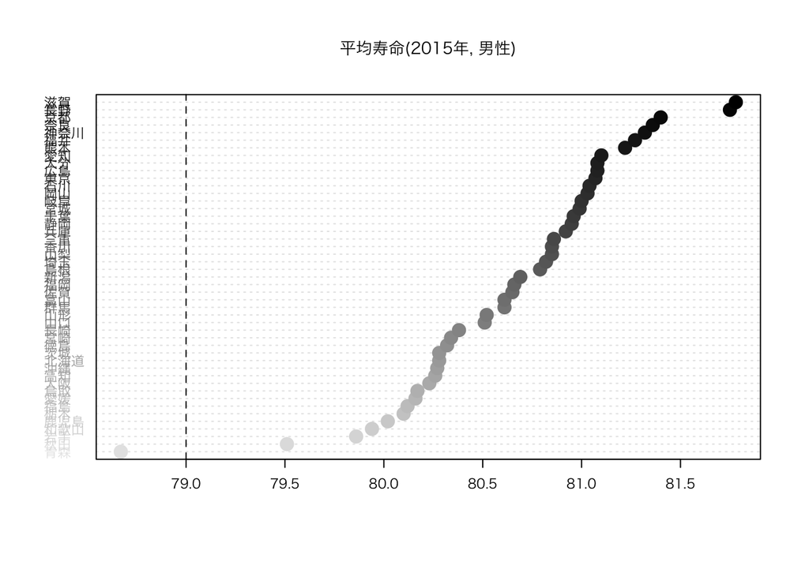

```r
jc.dotplot <- function(x) {
  # x is HLE or LE in c()　vector
  names(x)<-Wakayama::pref$pref.J
  x<-x[order(x)]

}

colfunc <- colorRampPalette(c("gray90","black"))

par(family= "HiraKakuProN-W3")

dotchart(
  main = "平均寿命(2015年, 男性)",
  jc.dotplot(d_m$LE_2015),
  cex = 0.7,
  lcolor = "gray90",
  pch = 19,
  col = colfunc(47),
  pt.cex = 1.5
)

abline(v = 79, lty = 2)
```

## 4.2 男性の健康寿命

```r
d_m %>% select(HLE_2016) %>% bind_cols(Wakayama::pref["pref.J"]) %>% dplyr::arrange(HLE_2016) %>% mutate(rank=row_number()) %>%DT::datatable()
```

|  | HLE_2016 | pref.J | rank |
| --- | --- | --- | --- |
| 1 | 71.21 | 秋田 | 1 |
| 2 | 71.33 | 愛媛 | 2 |
| 3 | 71.34 | 徳島 | 3 |
| 4 | 71.36 | 和歌山 | 4 |
| 5 | 71.37 | 高知 | 5 |
| 6 | 71.39 | 奈良 | 6 |
| 7 | 71.49 | 福岡 | 7 |
| 8 | 71.5 | 大阪 | 8 |
| 9 | 71.54 | 福島 | 9 |
| 10 | 71.54 | 岡山 | 10 |

[output cut: 37 more lines]

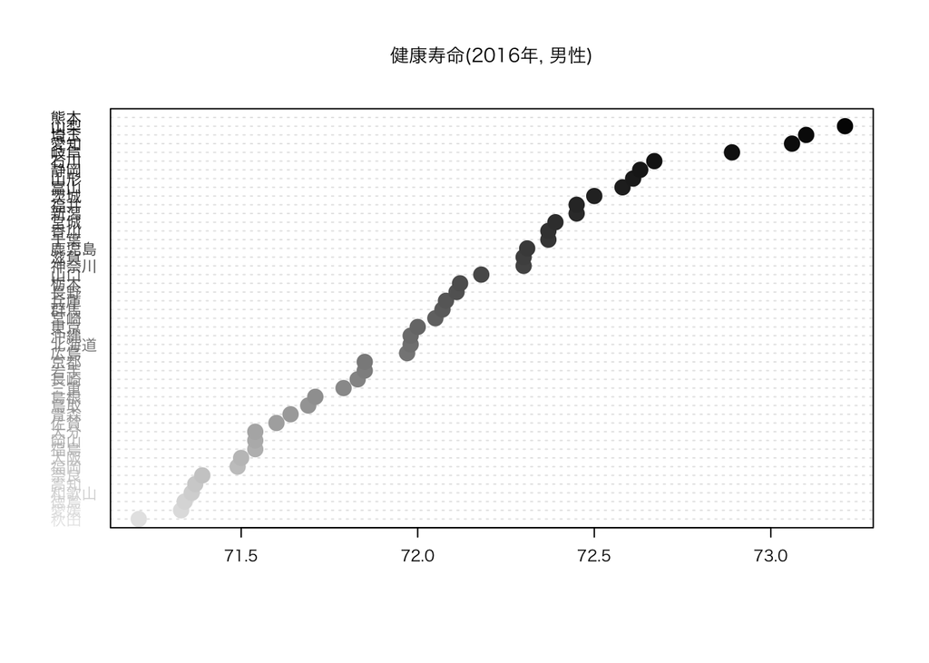

```r
jc.dotplot <- function(x) {
  # x is HLE or LE in c()　vector
  names(x)<-Wakayama::pref$pref.J
  x<-x[order(x)]

}

colfunc <- colorRampPalette(c("gray90","black"))

par(family= "HiraKakuProN-W3")

dotchart(
  main = "健康寿命(2016年, 男性)",
  jc.dotplot(d_m$HLE_2016),
  cex = 0.7,
  lcolor = "gray90",
  pch = 19,
  col = colfunc(47),
  pt.cex = 1.5
)

abline(v = 79, lty = 2)
```

## 4.3 女性の平均寿命

```r
d_f %>% select(LE_2015) %>% bind_cols(Wakayama::pref["pref.J"]) %>% dplyr::arrange(LE_2015) %>% mutate(rank=row_number()) %>%DT::datatable()
```

|  | LE_2015 | pref.J | rank |
| --- | --- | --- | --- |
| 1 | 85.93 | 青森 | 1 |
| 2 | 86.24 | 栃木 | 2 |
| 3 | 86.33 | 茨城 | 3 |
| 4 | 86.38 | 秋田 | 4 |
| 5 | 86.4 | 福島 | 5 |
| 6 | 86.44 | 岩手 | 6 |
| 7 | 86.47 | 和歌山 | 7 |
| 8 | 86.66 | 埼玉 | 8 |
| 9 | 86.66 | 徳島 | 9 |
| 10 | 86.73 | 大阪 | 10 |

[output cut: 37 more lines]

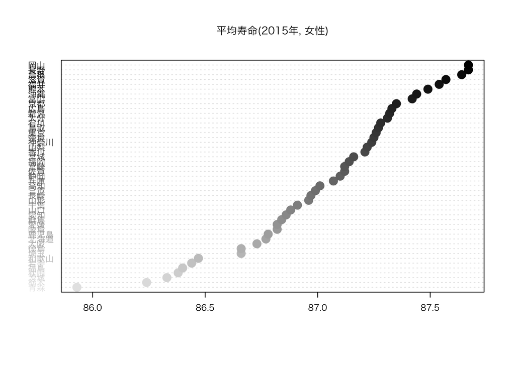

```r
jc.dotplot <- function(x) {
  # x is HLE or LE in c()　vector
  names(x)<-Wakayama::pref$pref.J
  x<-x[order(x)]

}

colfunc <- colorRampPalette(c("gray90","black"))

par(family= "HiraKakuProN-W3")

dotchart(
  main = "平均寿命(2015年, 女性)",
  jc.dotplot(d_f$LE_2015),
  cex = 0.7,
  lcolor = "gray90",
  pch = 19,
  col = colfunc(47),
  pt.cex = 1.5
)

abline(v = 79, lty = 2)
```

## 4.4 女性の健康寿命

```r
d_f %>% select(HLE_2016) %>% bind_cols(Wakayama::pref["pref.J"]) %>% dplyr::arrange(HLE_2016) %>% mutate(rank=row_number()) %>%DT::datatable()
```

|  | HLE_2016 | pref.J | rank |
| --- | --- | --- | --- |
| 1 | 73.62 | 広島 | 1 |
| 2 | 73.77 | 北海道 | 2 |
| 3 | 73.97 | 京都 | 3 |
| 4 | 74.04 | 徳島 | 4 |
| 5 | 74.07 | 滋賀 | 5 |
| 6 | 74.1 | 奈良 | 6 |
| 7 | 74.14 | 鳥取 | 7 |
| 8 | 74.23 | 兵庫 | 8 |
| 9 | 74.24 | 東京 | 9 |
| 10 | 74.42 | 和歌山 | 10 |

[output cut: 37 more lines]

[figure not shown]

```r
jc.dotplot <- function(x) {
  # x is HLE or LE in c()　vector
  names(x)<-Wakayama::pref$pref.J
  x<-x[order(x)]

}

colfunc <- colorRampPalette(c("gray90","black"))

par(family= "HiraKakuProN-W3")

dotchart(
  main = "平均寿命(2015年, 女性)",
  jc.dotplot(d_f$HLE_2016),
  cex = 0.7,
  lcolor = "gray90",
  pch = 19,
  col = colfunc(47),
  pt.cex = 1.5
)

abline(v = 79, lty = 2)
```

# 5 説明変数の順位確認

# 6 出典整理

- [受療率_入院_悪性新生物_2017](https://www.e-stat.go.jp/stat-search/files?page=1&layout=datalist&toukei=00450022&tstat=000001031167&cycle=7&tclass1=000001124800&tclass2=000001124802)
- [受療率_入院_心疾患_2017](https://www.e-stat.go.jp/stat-search/files?page=1&layout=datalist&toukei=00450022&tstat=000001031167&cycle=7&tclass1=000001124800&tclass2=000001124802)
- [受療率_入院_脳血管疾患_2017](https://www.e-stat.go.jp/stat-search/files?page=1&layout=datalist&toukei=00450022&tstat=000001031167&cycle=7&tclass1=000001124800&tclass2=000001124802)
- [受療率_外来_悪性新生物_2017](https://www.e-stat.go.jp/stat-search/files?page=1&layout=datalist&toukei=00450022&tstat=000001031167&cycle=7&tclass1=000001124800&tclass2=000001124802)
- [受療率_外来_心疾患_2017](https://www.e-stat.go.jp/stat-search/files?page=1&layout=datalist&toukei=00450022&tstat=000001031167&cycle=7&tclass1=000001124800&tclass2=000001124802)
- [受療率_外来_脳血管疾患_2017](https://www.e-stat.go.jp/stat-search/files?page=1&layout=datalist&toukei=00450022&tstat=000001031167&cycle=7&tclass1=000001124800&tclass2=000001124802)
- [病院数_2019](https://www.mhlw.go.jp/toukei/saikin/hw/iryosd/19/)
- [診療所数_2019](https://www.mhlw.go.jp/toukei/saikin/hw/iryosd/19/)
- [がん治療認定医数_2020](https://www.jbct.jp/general/figure.html)
- [循環器専門医数_2020](https://www.j-circ.or.jp/senmoni_kensaku/)
- [内視鏡専門医数_2020](https://www.jges.net/medical/about/list/memberlist#92)
- [75歳未満調整死亡率_悪性新生物_2018](https://ganjoho.jp/reg_stat/statistics/dl/index.html#pref_mortality)
- 書籍購入代金_2019
- [平均寿命_2015](https://www.mhlw.go.jp/toukei/saikin/hw/life/tdfk15/index.html)
- [健康寿命_2016](http://toukei.umin.jp/kenkoujyumyou/)
- [75歳未満調整死亡率_悪政新生物_2019](https://ganjoho.jp/reg_stat/statistics/dl/index.html#pref_mortality)
- [年齢調整死亡率_心疾患_2015](https://www.mhlw.go.jp/toukei/saikin/hw/jinkou/other/15sibou/index.html)
- [年齢調整死亡率_脳血管疾患_2015](https://www.mhlw.go.jp/toukei/saikin/hw/jinkou/other/15sibou/index.html)
- [60歳以上人口_2015](http://www.stat.go.jp/data/kokusei/2015/kekka.html)
- [学習率_2016](https://www.e-stat.go.jp/stat-search/files?page=1&layout=datalist&toukei=00200533&tstat=000001095335&cycle=0&tclass1=000001095377&tclass2=000001095378&tclass3=000001095386&tclass4=000001095387)
- [読書率_2016](https://www.e-stat.go.jp/stat-search/files?page=1&layout=datalist&toukei=00200533&tstat=000001095335&cycle=0&tclass1=000001095377&tclass2=000001095378&tclass3=000001095386&tclass4=000001095389)
- [人口・世帯_年少人口割合2020](https://www.e-stat.go.jp/stat-search/files?page=1&layout=datalist&toukei=00200502&tstat=000001137306&cycle=0&year=20200&month=0&tclass1=000001137307)
- [人口・世帯_老年人口割合2020](https://www.e-stat.go.jp/stat-search/files?page=1&layout=datalist&toukei=00200502&tstat=000001137306&cycle=0&year=20200&month=0&tclass1=000001137307)
- [人口・世帯_生産年齢人口割合2020](https://www.e-stat.go.jp/stat-search/files?page=1&layout=datalist&toukei=00200502&tstat=000001137306&cycle=0&year=20200&month=0&tclass1=000001137307)
- [人口・世帯_粗死亡率2020](https://www.e-stat.go.jp/stat-search/files?page=1&layout=datalist&toukei=00200502&tstat=000001137306&cycle=0&year=20200&month=0&tclass1=000001137307)
- [人口・世帯_共働き世帯割合2020](https://www.e-stat.go.jp/stat-search/files?page=1&layout=datalist&toukei=00200502&tstat=000001137306&cycle=0&year=20200&month=0&tclass1=000001137307)
- [自然環境_年平均気温](https://www.e-stat.go.jp/stat-search/files?page=1&layout=datalist&toukei=00200502&tstat=000001137306&cycle=0&year=20200&month=0&tclass1=000001137307)
- [自然環境_年平均相対湿度](https://www.e-stat.go.jp/stat-search/files?page=1&layout=datalist&toukei=00200502&tstat=000001137306&cycle=0&year=20200&month=0&tclass1=000001137307)
- [自然環境_降水量（年間）](https://www.e-stat.go.jp/stat-search/files?page=1&layout=datalist&toukei=00200502&tstat=000001137306&cycle=0&year=20200&month=0&tclass1=000001137307)
- [自然環境_雪日数（年間）](https://www.e-stat.go.jp/stat-search/files?page=1&layout=datalist&toukei=00200502&tstat=000001137306&cycle=0&year=20200&month=0&tclass1=000001137307)
- [経済基盤_県民所得](https://www.e-stat.go.jp/stat-search/files?page=1&layout=datalist&toukei=00200502&tstat=000001137306&cycle=0&year=20200&month=0&tclass1=000001137307)
- [行政基盤_財政力指数](https://www.e-stat.go.jp/stat-search/files?page=1&layout=datalist&toukei=00200502&tstat=000001137306&cycle=0&year=20200&month=0&tclass1=000001137307)
- [行政基盤_収支比率](https://www.e-stat.go.jp/stat-search/files?page=1&layout=datalist&toukei=00200502&tstat=000001137306&cycle=0&year=20200&month=0&tclass1=000001137307)
- [行政基盤_生活保護費割合（県財政）](https://www.e-stat.go.jp/stat-search/files?page=1&layout=datalist&toukei=00200502&tstat=000001137306&cycle=0&year=20200&month=0&tclass1=000001137307)
- [行政基盤_教育費割合（県財政）](https://www.e-stat.go.jp/stat-search/files?page=1&layout=datalist&toukei=00200502&tstat=000001137306&cycle=0&year=20200&month=0&tclass1=000001137307)
- [教育_最終学歴が大学・大学院卒の者の割合](https://www.e-stat.go.jp/stat-search/files?page=1&layout=datalist&toukei=00200502&tstat=000001137306&cycle=0&year=20200&month=0&tclass1=000001137307)
- [労働_１次産業就業者比率](https://www.e-stat.go.jp/stat-search/files?page=1&layout=datalist&toukei=00200502&tstat=000001137306&cycle=0&year=20200&month=0&tclass1=000001137307)
- [労働_２次産業就業者比率](https://www.e-stat.go.jp/stat-search/files?page=1&layout=datalist&toukei=00200502&tstat=000001137306&cycle=0&year=20200&month=0&tclass1=000001137307)
- [労働_３次産業就業者比率](https://www.e-stat.go.jp/stat-search/files?page=1&layout=datalist&toukei=00200502&tstat=000001137306&cycle=0&year=20200&month=0&tclass1=000001137307)
- [労働_完全失業率](https://www.e-stat.go.jp/stat-search/files?page=1&layout=datalist&toukei=00200502&tstat=000001137306&cycle=0&year=20200&month=0&tclass1=000001137307)
- [文化・スポーツ_図書館数（人口100万人当たり）](https://www.e-stat.go.jp/stat-search/files?page=1&layout=datalist&toukei=00200502&tstat=000001137306&cycle=0&year=20200&month=0&tclass1=000001137307)
- [健康・医療_一般診療所数(可住地面積100k㎡当たり)](https://www.e-stat.go.jp/stat-search/files?page=1&layout=datalist&toukei=00200502&tstat=000001137306&cycle=0&year=20200&month=0&tclass1=000001137307)
- [文化・スポーツ_スポーツの行動者率](https://www.e-stat.go.jp/stat-search/files?page=1&layout=datalist&toukei=00200502&tstat=000001137306&cycle=0&year=20200&month=0&tclass1=000001137307)
- [文化・スポーツ_旅行・行楽行動者率](https://www.e-stat.go.jp/stat-search/files?page=1&layout=datalist&toukei=00200502&tstat=000001137306&cycle=0&year=20200&month=0&tclass1=000001137307)
- [居住_持ち家比率](https://www.e-stat.go.jp/stat-search/files?page=1&layout=datalist&toukei=00200502&tstat=000001137306&cycle=0&year=20200&month=0&tclass1=000001137307)
- [居住_一戸建住宅比率](https://www.e-stat.go.jp/stat-search/files?page=1&layout=datalist&toukei=00200502&tstat=000001137306&cycle=0&year=20200&month=0&tclass1=000001137307)
- [居住_上水道給水人口比率](https://www.e-stat.go.jp/stat-search/files?page=1&layout=datalist&toukei=00200502&tstat=000001137306&cycle=0&year=20200&month=0&tclass1=000001137307)
- [居住_下水道普及比率](https://www.e-stat.go.jp/stat-search/files?page=1&layout=datalist&toukei=00200502&tstat=000001137306&cycle=0&year=20200&month=0&tclass1=000001137307)
- [文化・スポーツ_ボランティア活動行動者率](https://www.e-stat.go.jp/stat-search/files?page=1&layout=datalist&toukei=00200502&tstat=000001137306&cycle=0&year=20200&month=0&tclass1=000001137307)
- [居住_都市公園面積（人口１人当たり）](https://www.e-stat.go.jp/stat-search/files?page=1&layout=datalist&toukei=00200502&tstat=000001137306&cycle=0&year=20200&month=0&tclass1=000001137307)
- [居住_都市公園数(可住地面積100k㎡当たり)](https://www.e-stat.go.jp/stat-search/files?page=1&layout=datalist&toukei=00200502&tstat=000001137306&cycle=0&year=20200&month=0&tclass1=000001137307)
- [健康・医療_一般病院数(可住地面積100k㎡当たり)](https://www.e-stat.go.jp/stat-search/files?page=1&layout=datalist&toukei=00200502&tstat=000001137306&cycle=0&year=20200&month=0&tclass1=000001137307)
- [居住_主要道路舗装率](https://www.e-stat.go.jp/stat-search/files?page=1&layout=datalist&toukei=00200502&tstat=000001137306&cycle=0&year=20200&month=0&tclass1=000001137307)
- [居住_市町村舗装率](https://www.e-stat.go.jp/stat-search/files?page=1&layout=datalist&toukei=00200502&tstat=000001137306&cycle=0&year=20200&month=0&tclass1=000001137307)
- [健康・医療_一般歯科診療所数（人口10万人当たり）](https://www.e-stat.go.jp/stat-search/files?page=1&layout=datalist&toukei=00200502&tstat=000001137306&cycle=0&year=20200&month=0&tclass1=000001137307)
- [健康・医療_医療施設に従事する医師数（人口10万人当たり）](https://www.e-stat.go.jp/stat-search/files?page=1&layout=datalist&toukei=00200502&tstat=000001137306&cycle=0&year=20200&month=0&tclass1=000001137307)
- [健康・医療_保健師数（人口10万人当たり）](https://www.e-stat.go.jp/stat-search/files?page=1&layout=datalist&toukei=00200502&tstat=000001137306&cycle=0&year=20200&month=0&tclass1=000001137307)
- [安全_交通事故発生件数（人口10万人当たり）](https://www.e-stat.go.jp/stat-search/files?page=1&layout=datalist&toukei=00200502&tstat=000001137306&cycle=0&year=20200&month=0&tclass1=000001137307)
- [家計_実収入（一世帯当たり１か月）](https://www.e-stat.go.jp/stat-search/files?page=1&layout=datalist&toukei=00200502&tstat=000001137306&cycle=0&year=20200&month=0&tclass1=000001137307)
- [家計_消費支出（一世帯当たり１か月）](https://www.e-stat.go.jp/stat-search/files?page=1&layout=datalist&toukei=00200502&tstat=000001137306&cycle=0&year=20200&month=0&tclass1=000001137307)
- [家計_教育費割合（対消費支出）](https://www.e-stat.go.jp/stat-search/files?page=1&layout=datalist&toukei=00200502&tstat=000001137306&cycle=0&year=20200&month=0&tclass1=000001137307)
- [家計_教養娯楽費割合（対消費支出）](https://www.e-stat.go.jp/stat-search/files?page=1&layout=datalist&toukei=00200502&tstat=000001137306&cycle=0&year=20200&month=0&tclass1=000001137307)
- [家計_貯蓄現在高](https://www.e-stat.go.jp/stat-search/files?page=1&layout=datalist&toukei=00200502&tstat=000001137306&cycle=0&year=20200&month=0&tclass1=000001137307)
- [家計_スマートフォン所有数量（千世帯当たり）](https://www.e-stat.go.jp/stat-search/files?page=1&layout=datalist&toukei=00200502&tstat=000001137306&cycle=0&year=20200&month=0&tclass1=000001137307)
- [家計_パソコン所有数量（千世帯当たり）](https://www.e-stat.go.jp/stat-search/files?page=1&layout=datalist&toukei=00200502&tstat=000001137306&cycle=0&year=20200&month=0&tclass1=000001137307)
- [家計_自動車所有数量（千世帯当たり）](https://www.e-stat.go.jp/stat-search/files?page=1&layout=datalist&toukei=00200502&tstat=000001137306&cycle=0&year=20200&month=0&tclass1=000001137307)
- [家計_タブレット端末所有数量（千世帯当たり）](https://www.e-stat.go.jp/stat-search/files?page=1&layout=datalist&toukei=00200502&tstat=000001137306&cycle=0&year=20200&month=0&tclass1=000001137307)
- [人口・世帯_高齢単身者世帯の割合](https://www.e-stat.go.jp/stat-search/files?page=1&layout=datalist&toukei=00200502&tstat=000001137306&cycle=0&year=20200&month=0&tclass1=000001137307)
- スポーツ総行動率
- スポーツ総行動率-器具を使ったトレーニング
- スポーツ行動率−ウォーキング
- [旅行・行楽−旅行・行楽・観光総行動率](https://www.e-stat.go.jp/stat-search/files?page=1&layout=datalist&toukei=00200533&tstat=000001095335&cycle=0&tclass1=000001095377&tclass2=000001095378&tclass3=000001095386&tclass4=000001095391)
- [旅行・行楽−旅行率](https://www.e-stat.go.jp/stat-search/files?page=1&layout=datalist&toukei=00200533&tstat=000001095335&cycle=0&tclass1=000001095377&tclass2=000001095378&tclass3=000001095386&tclass4=000001095391)
- [旅行・行楽−行楽率](https://www.e-stat.go.jp/stat-search/files?page=1&layout=datalist&toukei=00200533&tstat=000001095335&cycle=0&tclass1=000001095377&tclass2=000001095378&tclass3=000001095386&tclass4=000001095391)
- [旅行・行楽−観光率](https://www.e-stat.go.jp/stat-search/files?page=1&layout=datalist&toukei=00200533&tstat=000001095335&cycle=0&tclass1=000001095377&tclass2=000001095378&tclass3=000001095386&tclass4=000001095391)
- [ボランティア総行動率−総数](https://www.e-stat.go.jp/stat-search/files?page=1&layout=datalist&toukei=00200533&tstat=000001095335&cycle=0&tclass1=000001095377&tclass2=000001095378&tclass3=000001095386&tclass4=000001095390)
- [ボランティア総行動率−まちづくり活動](https://www.e-stat.go.jp/stat-search/files?page=1&layout=datalist&toukei=00200533&tstat=000001095335&cycle=0&tclass1=000001095377&tclass2=000001095378&tclass3=000001095386&tclass4=000001095390)
- [ボランティア総行動率−国際協力活動](https://www.e-stat.go.jp/stat-search/files?page=1&layout=datalist&toukei=00200533&tstat=000001095335&cycle=0&tclass1=000001095377&tclass2=000001095378&tclass3=000001095386&tclass4=000001095390)
- [ボランティア総行動率−健康や医療サービスに関係した活動](https://www.e-stat.go.jp/stat-search/files?page=1&layout=datalist&toukei=00200533&tstat=000001095335&cycle=0&tclass1=000001095377&tclass2=000001095378&tclass3=000001095386&tclass4=000001095390)
- [ボランティア総行動率−高齢者を対象とした活動](https://www.e-stat.go.jp/stat-search/files?page=1&layout=datalist&toukei=00200533&tstat=000001095335&cycle=0&tclass1=000001095377&tclass2=000001095378&tclass3=000001095386&tclass4=000001095390)
- [ボランティア総行動率−障害者を対象とした活動](https://www.e-stat.go.jp/stat-search/files?page=1&layout=datalist&toukei=00200533&tstat=000001095335&cycle=0&tclass1=000001095377&tclass2=000001095378&tclass3=000001095386&tclass4=000001095390)
- [ボランティア総行動率−子供を対象とした活動](https://www.e-stat.go.jp/stat-search/files?page=1&layout=datalist&toukei=00200533&tstat=000001095335&cycle=0&tclass1=000001095377&tclass2=000001095378&tclass3=000001095386&tclass4=000001095390)
- [趣味・娯楽−趣味娯楽総行動率](https://www.e-stat.go.jp/stat-search/files?page=1&layout=datalist&toukei=00200533&tstat=000001095335&cycle=0&tclass1=000001095377&tclass2=000001095378&tclass3=000001095386&tclass4=000001095389)
- [趣味・娯楽−園芸・庭いじり・ガーデニング](https://www.e-stat.go.jp/stat-search/files?page=1&layout=datalist&toukei=00200533&tstat=000001095335&cycle=0&tclass1=000001095377&tclass2=000001095378&tclass3=000001095386&tclass4=000001095389)
- [趣味・娯楽−スポーツ観覧](https://www.e-stat.go.jp/stat-search/files?page=1&layout=datalist&toukei=00200533&tstat=000001095335&cycle=0&tclass1=000001095377&tclass2=000001095378&tclass3=000001095386&tclass4=000001095389)
- [趣味・娯楽−読書](https://www.e-stat.go.jp/stat-search/files?page=1&layout=datalist&toukei=00200533&tstat=000001095335&cycle=0&tclass1=000001095377&tclass2=000001095378&tclass3=000001095386&tclass4=000001095389)
- [自己啓発・訓練−学習・自己啓発・訓練率](https://www.e-stat.go.jp/stat-search/files?page=1&layout=datalist&toukei=00200533&tstat=000001095335&cycle=0&tclass1=000001095377&tclass2=000001095378&tclass3=000001095386&tclass4=000001095387)
- [自己啓発・訓練−芸術・文化](https://www.e-stat.go.jp/stat-search/files?page=1&layout=datalist&toukei=00200533&tstat=000001095335&cycle=0&tclass1=000001095377&tclass2=000001095378&tclass3=000001095386&tclass4=000001095387)
- [自己啓発・訓練−英語](https://www.e-stat.go.jp/stat-search/files?page=1&layout=datalist&toukei=00200533&tstat=000001095335&cycle=0&tclass1=000001095377&tclass2=000001095378&tclass3=000001095386&tclass4=000001095387)
- [自己啓発・訓練−英語以外の外国語](https://www.e-stat.go.jp/stat-search/files?page=1&layout=datalist&toukei=00200533&tstat=000001095335&cycle=0&tclass1=000001095377&tclass2=000001095378&tclass3=000001095386&tclass4=000001095387)
- [自己啓発・訓練−パソコンなどの情報処理](https://www.e-stat.go.jp/stat-search/files?page=1&layout=datalist&toukei=00200533&tstat=000001095335&cycle=0&tclass1=000001095377&tclass2=000001095378&tclass3=000001095386&tclass4=000001095387)
- [ボランティア活動−安全な生活のための活動](https://www.e-stat.go.jp/stat-search/files?page=1&layout=datalist&toukei=00200533&tstat=000001095335&cycle=0&tclass1=000001095377&tclass2=000001095378&tclass3=000001095386&tclass4=000001095390&tclass5val=0)
- [ボランティア活動−自然や環境の活動](https://www.e-stat.go.jp/stat-search/files?page=1&layout=datalist&toukei=00200533&tstat=000001095335&cycle=0&tclass1=000001095377&tclass2=000001095378&tclass3=000001095386&tclass4=000001095390&tclass5val=0)
- [ボランティア活動−災害活動](https://www.e-stat.go.jp/stat-search/files?page=1&layout=datalist&toukei=00200533&tstat=000001095335&cycle=0&tclass1=000001095377&tclass2=000001095378&tclass3=000001095386&tclass4=000001095390&tclass5val=0)
- [高血圧疾患_入院2014年](https://www.e-stat.go.jp/stat-search/files?page=1&layout=datalist&toukei=00450022&tstat=000001031167&cycle=7&tclass1=000001077497&tclass2=000001077499&tclass3val=0)
- [高血圧疾患_外来2014年](https://www.e-stat.go.jp/stat-search/files?page=1&layout=datalist&toukei=00450022&tstat=000001031167&cycle=7&tclass1=000001077497&tclass2=000001077499&tclass3val=0)
- [糖尿病_入院2014年](https://www.e-stat.go.jp/stat-search/files?page=1&layout=datalist&toukei=00450022&tstat=000001031167&cycle=7&tclass1=000001077497&tclass2=000001077499&tclass3val=0)
- [糖尿病_外来2014年](https://www.e-stat.go.jp/stat-search/files?page=1&layout=datalist&toukei=00450022&tstat=000001031167&cycle=7&tclass1=000001077497&tclass2=000001077499&tclass3val=0)
- [脳血管疾患_年齢調整死亡率2015](https://www.e-stat.go.jp/stat-search/files?page=1&layout=datalist&toukei=00450013&tstat=000001102115&cycle=7&year=20150&month=0)
- [悪性新生物(胃)_年齢調整死亡率2015](https://www.e-stat.go.jp/stat-search/files?page=1&layout=datalist&toukei=00450013&tstat=000001102115&cycle=7&year=20150&month=0&tclass1val=0)
- [悪性新生物(大腸)_年齢調整死亡率2015](https://www.e-stat.go.jp/stat-search/files?page=1&layout=datalist&toukei=00450013&tstat=000001102115&cycle=7&year=20150&month=0)
- [悪性新生物(肝及び肝内胆管)_年齢調整死亡率2015](https://www.e-stat.go.jp/stat-search/files?page=1&layout=datalist&toukei=00450013&tstat=000001102115&cycle=7&year=20150&month=0&tclass1val=0)
- [悪性新生物(気管、気管支及び肺)_年齢調整死亡率2015](https://www.e-stat.go.jp/stat-search/files?page=1&layout=datalist&toukei=00450013&tstat=000001102115&cycle=7&year=20150&month=0&tclass1val=0)
- [悪性新生物(乳房)_年齢調整死亡率2015](https://www.e-stat.go.jp/stat-search/files?page=1&layout=datalist&toukei=00450013&tstat=000001102115&cycle=7&year=20150&month=0&tclass1val=0)
- [悪性新生物(子宮)_年齢調整死亡率2015](https://www.e-stat.go.jp/stat-search/files?page=1&layout=datalist&toukei=00450022&tstat=000001031167&cycle=7&tclass1=000001077497&tclass2=000001077499&tclass3val=0)
- [心疾患_年齢調整死亡率2015](https://www.e-stat.go.jp/stat-search/files?page=1&layout=datalist&toukei=00450022&tstat=000001031167&cycle=7&tclass1=000001077497&tclass2=000001077499&tclass3val=0)
- [肺炎_年齢調整死亡率2015](https://www.e-stat.go.jp/stat-search/files?page=1&layout=datalist&toukei=00450022&tstat=000001031167&cycle=7&tclass1=000001077497&tclass2=000001077499&tclass3val=0)
- [急性心筋梗塞_年齢調整死亡率2015](https://www.e-stat.go.jp/stat-search/files?page=1&layout=datalist&toukei=00450022&tstat=000001031167&cycle=7&tclass1=000001077497&tclass2=000001077499&tclass3val=0)
- [血圧を下げる薬の使用_回答・はい(40〜64歳)2014](https://www.mhlw.go.jp/stf/seisakunitsuite/bunya/0000177221.html)
- [インシュリン注射、血糖を下げる薬の使用_回答・はい(40〜74歳)2014](https://www.mhlw.go.jp/stf/seisakunitsuite/bunya/0000177221.html)
- [コレステロールを下げる薬の使用_回答・はい(40〜74歳)2014](https://www.mhlw.go.jp/stf/seisakunitsuite/bunya/0000177221.html)
- [就寝前の2時間以内に夕食_回答・はい(40〜74歳)2014](https://www.mhlw.go.jp/stf/seisakunitsuite/bunya/0000177221.html)
- [日常生活において歩行等の身体活動(1日1時間以上実施)_回答・はい(40〜74歳)2014](https://www.mhlw.go.jp/stf/seisakunitsuite/bunya/0000177221.html)
- [軽く汗をかく運動週2回_回答・はい(40〜74歳)2014](https://www.mhlw.go.jp/stf/seisakunitsuite/bunya/0000177221.html)
- ["喫煙率(計100本以上,6ヵ月以上&直近1ヵ月)_回答・はい(40〜74歳)2014"](https://www.mhlw.go.jp/stf/seisakunitsuite/bunya/0000177221.html)
- [20歳に比べて10kg体重増加.回答_はい(40〜74歳)2014](https://www.mhlw.go.jp/stf/seisakunitsuite/bunya/0000177221.html)
- [歩く速度が速い(同年齢と比較).回答_はい(40〜74歳)2014](https://www.mhlw.go.jp/stf/seisakunitsuite/bunya/0000177221.html)
- [飲酒日1日当たり2合以上飲む割合(頻度)_回答・はい(40〜74歳)2014](https://www.mhlw.go.jp/stf/seisakunitsuite/bunya/0000177221.html)
- [毎日酒を飲む割合(頻度)_回答・はい(40〜74歳)2014](https://www.mhlw.go.jp/stf/seisakunitsuite/bunya/0000177221.html)
- [睡眠休養が十分とれている.回答_はい(40〜74歳)2014](https://www.mhlw.go.jp/stf/seisakunitsuite/bunya/0000177221.html)
- [朝食を抜くことが週3回ある.回答_はい(40〜74歳)2014](https://www.mhlw.go.jp/stf/seisakunitsuite/bunya/0000177221.html)
- [夕食後に間食することが週3回ある.回答_はい(40〜74歳)2014](https://www.mhlw.go.jp/stf/seisakunitsuite/bunya/0000177221.html)
- [肉類_2014](https://www.e-stat.go.jp/stat-search?page=1&query=%E5%93%81%E7%9B%AE%E5%88%86%E9%A1%9E%E3%80%80%E7%AC%AC11%E8%A1%A8&layout=dataset&file_type=0)
- [魚介類_2014](https://www.e-stat.go.jp/stat-search?page=1&query=%E5%93%81%E7%9B%AE%E5%88%86%E9%A1%9E%E3%80%80%E7%AC%AC11%E8%A1%A8&layout=dataset&file_type=0)
- [牛乳_2014](https://www.e-stat.go.jp/stat-search?page=1&query=%E5%93%81%E7%9B%AE%E5%88%86%E9%A1%9E%E3%80%80%E7%AC%AC11%E8%A1%A8&layout=dataset&file_type=0)
- [乳製品_2014](https://www.e-stat.go.jp/stat-search?page=1&query=%E5%93%81%E7%9B%AE%E5%88%86%E9%A1%9E%E3%80%80%E7%AC%AC11%E8%A1%A8&layout=dataset&file_type=0)
- [卵_2014](https://www.e-stat.go.jp/stat-search?page=1&query=%E5%93%81%E7%9B%AE%E5%88%86%E9%A1%9E%E3%80%80%E7%AC%AC11%E8%A1%A8&layout=dataset&file_type=0)
- [大豆_2014](https://www.e-stat.go.jp/stat-search?page=1&query=%E5%93%81%E7%9B%AE%E5%88%86%E9%A1%9E%E3%80%80%E7%AC%AC11%E8%A1%A8&layout=dataset&file_type=0)
- 一定のバリアフリー化率手すりの設置_2013
- [一定のバリアフリー化率段差のない屋内_2013]
- [高度のバリアフリー化率手すりの設置_2013]
- [高度のバリアフリー化率段差のない屋内_2013]
- [高度のバリアフリー廊下等が車いすで通行可能な幅_2013]
- [総実労働時間_2016]
- [現金給与総額_2016]
- [生鮮肉(世帯数消費支出)_2014]
- [生鮮肉(世帯数消費支出)_2015]
- [生鮮肉(世帯数消費支出)_2016]
- [生鮮肉平均_世帯数消費支出(2014〜2016）]
- [菓子類(世帯数消費支出)_2014]
- [菓子類(世帯数消費支出)_2015]
- [菓子類(世帯数消費支出)_2016]
- [菓子類平均_世帯数消費支出(2014〜2016）]
- [果物(世帯数消費支出)_2014]
- [果物(世帯数消費支出)_2015]
- [果物(世帯数消費支出)_2016]
- [果物平均_世帯数消費支出(2014〜2016）]
- [全国学力・学習状況(公立学校数)(中学校)_2015]
- [全国学力・学習状況(公立学校数)(小学生)_2015]
- [う蝕外来総数_2014]
- [歯周疾患(歯肉炎)外来総数_2014]
- [骨の密度障害_2014]
- [骨折_2014]
- [歯の補てつ_2014]
- [アルツハイマー等(脳血管疾患)_2014]
- [ジニ係数総世帯_2014]
- [収入ジニ係数勤労世帯_2014]
- [野菜摂取量_2012(20歳以上平均値(g/日)]
- [食塩摂取量_2012(20歳以上平均値(g/日)](https://www.mhlw.go.jp/stf/houdou/...att/2r98520000021c39.pdf)
- [BMI平均値_2012(男性20〜69歳)(女性40〜69歳)(単位Kg/㎡)](https://www.mhlw.go.jp/bunya/kenkou/eiyou/dl/h28-houkoku-07.pdf)
- [歩数_2012(20歳以上平均値(歩/日)](https://www.mhlw.go.jp/stf/houdou/...att/2r98520000021c39.pdf)